# Power calculations

2023-01-11

# Power calculations

**Project number**: 2233

**Project name**: USWDS Digital Dashboard

**Author**: Ben Jaques-Leslie

**Data**: wds.rdata’

## Load data

### Data from wds.rdata

```r
load(here::here("03. Data Collection",params$data))
```

Review data.

```r
d %>% skim()
```

Data summary

| Name | Piped data |
| --- | --- |
| Number of rows | 102154 |
| Number of columns | 6 |
| _______________________ |  |
| Column type frequency: |  |
| character | 1 |
| Date | 3 |
| factor | 1 |
| numeric | 1 |
| ________________________ |  |
| Group variables | None |

**Variable type: character**

| skim_variable | n_missing | complete_rate | min | max | empty | n_unique | whitespace |
| --- | --- | --- | --- | --- | --- | --- | --- |
| website | 0 | 1 | 6 | 37 | 0 | 1131 | 0 |

**Variable type: Date**

| skim_variable | n_missing | complete_rate | min | max | median | n_unique |
| --- | --- | --- | --- | --- | --- | --- |
| date | 0 | 1 | 2017-12-28 | 2022-03-16 | 2019-10-28 | 133 |
| date_month | 0 | 1 | 2017-12-01 | 2022-03-01 | 2019-10-01 | 48 |
| date_week | 0 | 1 | 2017-12-24 | 2022-03-13 | 2019-10-27 | 91 |

**Variable type: factor**

| skim_variable | n_missing | complete_rate | ordered | n_unique | top_counts |
| --- | --- | --- | --- | --- | --- |
| name | 0 | 1 | FALSE | 4 | htm: 32125, col: 32116, mis: 32111, usw: 5802 |

**Variable type: numeric**

| skim_variable | n_missing | complete_rate | mean | sd | p0 | p25 | p50 | p75 | p100 | hist |
| --- | --- | --- | --- | --- | --- | --- | --- | --- | --- | --- |
| value | 33873 | 0.67 | 9.91 | 23.65 | 0 | 0 | 2 | 7 | 761 | ▇▁▁▁▁ |

Review the data by outcome and treatment.

```r
d %>% group_by(name) %>%  skim()
```

Data summary

| Name | Piped data |
| --- | --- |
| Number of rows | 102154 |
| Number of columns | 6 |
| _______________________ |  |
| Column type frequency: |  |
| character | 1 |
| Date | 3 |
| numeric | 1 |
| ________________________ |  |
| Group variables | name |

**Variable type: character**

| skim_variable | name | n_missing | complete_rate | min | max | empty | n_unique | whitespace |
| --- | --- | --- | --- | --- | --- | --- | --- | --- |
| website | color_contrast_issues | 0 | 1 | 6 | 37 | 0 | 1112 | 0 |
| website | html_aattribute_issues | 0 | 1 | 6 | 37 | 0 | 1112 | 0 |
| website | missing_image_issues | 0 | 1 | 6 | 37 | 0 | 1112 | 0 |
| website | uswds_score | 0 | 1 | 6 | 33 | 0 | 99 | 0 |

**Variable type: Date**

| skim_variable | name | n_missing | complete_rate | min | max | median | n_unique |
| --- | --- | --- | --- | --- | --- | --- | --- |
| date | color_contrast_issues | 0 | 1 | 2017-12-28 | 2022-03-06 | 2019-10-07 | 97 |
| date | html_aattribute_issues | 0 | 1 | 2017-12-28 | 2022-03-06 | 2019-10-07 | 97 |
| date | missing_image_issues | 0 | 1 | 2017-12-28 | 2022-03-06 | 2019-10-07 | 97 |
| date | uswds_score | 0 | 1 | 2020-06-18 | 2022-03-16 | 2021-05-19 | 81 |
| date_month | color_contrast_issues | 0 | 1 | 2017-12-01 | 2022-03-01 | 2019-10-01 | 47 |
| date_month | html_aattribute_issues | 0 | 1 | 2017-12-01 | 2022-03-01 | 2019-10-01 | 47 |
| date_month | missing_image_issues | 0 | 1 | 2017-12-01 | 2022-03-01 | 2019-10-01 | 47 |
| date_month | uswds_score | 0 | 1 | 2020-06-01 | 2022-03-01 | 2021-05-01 | 22 |
| date_week | color_contrast_issues | 0 | 1 | 2017-12-24 | 2022-03-06 | 2019-10-06 | 81 |
| date_week | html_aattribute_issues | 0 | 1 | 2017-12-24 | 2022-03-06 | 2019-10-06 | 81 |
| date_week | missing_image_issues | 0 | 1 | 2017-12-24 | 2022-03-06 | 2019-10-06 | 81 |
| date_week | uswds_score | 0 | 1 | 2020-06-14 | 2022-03-13 | 2021-05-16 | 50 |

**Variable type: numeric**

| skim_variable | name | n_missing | complete_rate | mean | sd | p0 | p25 | p50 | p75 | p100 | hist |
| --- | --- | --- | --- | --- | --- | --- | --- | --- | --- | --- | --- |
| value | color_contrast_issues | 11022 | 0.66 | 8.69 | 21.24 | 0 | 1 | 3 | 10 | 761 | ▇▁▁▁▁ |
| value | html_aattribute_issues | 6168 | 0.81 | 6.28 | 12.78 | 0 | 1 | 2 | 6 | 307 | ▇▁▁▁▁ |
| value | missing_image_issues | 16661 | 0.48 | 3.49 | 6.49 | 0 | 0 | 1 | 4 | 69 | ▇▁▁▁▁ |
| value | uswds_score | 22 | 1.00 | 47.89 | 49.96 | 0 | 0 | 0 | 100 | 100 | ▇▁▁▁▇ |

## Understanding the outcome distribution

### Overall distribution of issues.

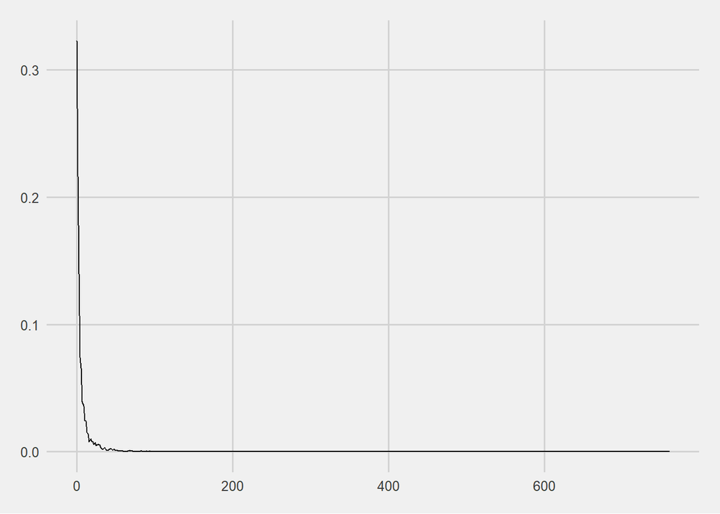

```r
d %>%
  filter(name != "uswds_score") %>%
  ggplot(aes(x = value)) +
  geom_density() +
  theme_fivethirtyeight() +
  scale_fill_oes()
```

### Distribution by issue count and WDS score.

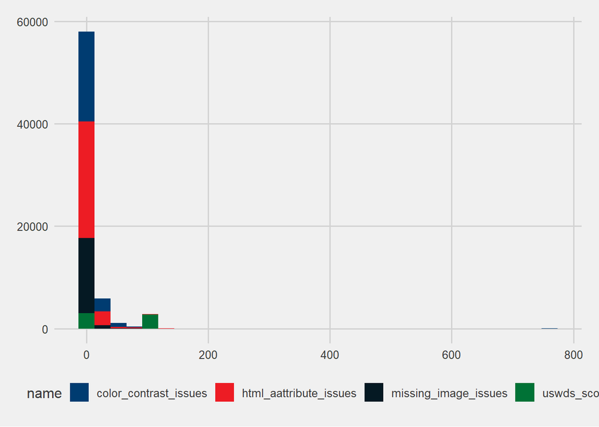

```r
d %>%
  ggplot(aes(x = value, fill = name)) +
  geom_histogram() +
  scale_fill_oes(palette = "full colors") +
  theme_fivethirtyeight()
```

When we treat the null values as zero, we have greater skew.

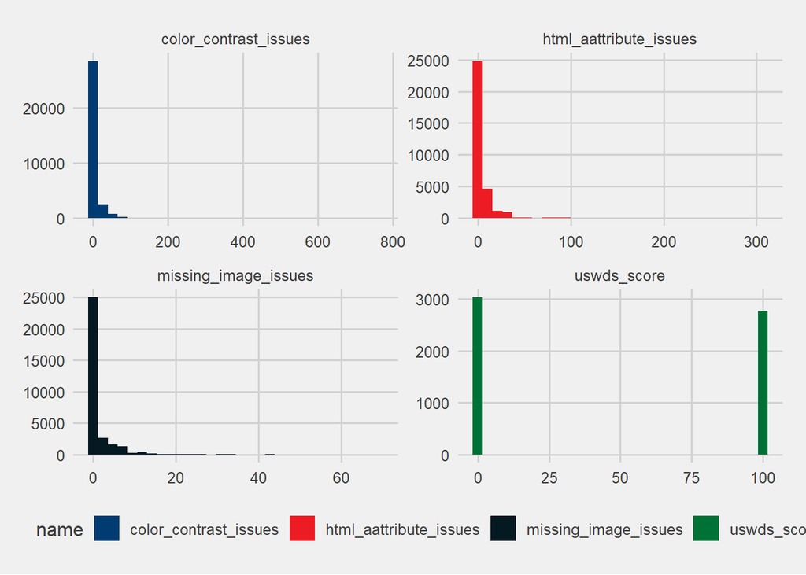

```r
d %>%
  mutate(value = replace_na(value, 0)) %>%
  ggplot(aes(x = value, fill = name)) +
  geom_histogram() +
  scale_fill_oes(palette = "full colors") +
  theme_fivethirtyeight() +
  facet_wrap('name', scales = "free")
```

## Power analysis

### Assumptions

Several assumptions are based off of the means and sample size of the USWDS data.

```r
prep_01 <-
  d %>%
  group_by(name) %>%
  summarise(mean = mean(value, na.rm = TRUE),
            websites = n_distinct(website)) %>%
  ungroup()

prep_01
```

```
## # A tibble: 4 × 3
##   name                    mean websites
##   <fct>                  <dbl>    <int>
## 1 color_contrast_issues   8.69     1112
## 2 html_aattribute_issues  6.28     1112
## 3 missing_image_issues    3.49     1112
## 4 uswds_score            47.9        99
```

Using the color contrast issues count as the primary outcome of interest. The assumed population mean is the mean issues.

```r
population_mean_color_contrast_issues <-
  prep_01 %>%
  filter(name == "color_contrast_issues") %>%
  pull(mean)

population_mean_color_contrast_issues
```

```
## [1] 8.694842
```

The populations size is the number of websites measured for color contrast issues.

```r
population_size_color_contrast_issues <-
  prep_01 %>%
  filter(name == "color_contrast_issues") %>%
  pull(websites)

population_size_color_contrast_issues
```

```
## [1] 1112
```

The proportion treated is the proportion of screened websites that have the USWDS indicator.

```r
population_treatement_proportion <-
  d %>%
  filter(name == "uswds_score") %>%
  filter(value == 100) %>%
  summarise(websites = n_distinct(website)) %>%
  pull(websites)/population_size_color_contrast_issues

population_treatement_proportion
```

```
## [1] 0.04856115
```

The assumed average treatment effect is -1. We are assuming that the use of USWDS will decrease the number of issues by -1.

Based on the evaluation of the outcome indicators above, we are assuming that the outcome indicators follow a negative binomial distribution.

The treatment effect is likely to come from a negative binomial distribution on the left side of zero as the treatment is unlikely to increase issues and follow a similar distribution to the outcome.

We calculate the treatment effect with this formula:

$$Y_1 = \beta_0 + \beta_1Treatment + \beta_2Y_0$$

### Calculating power

The function below calculates the betas based on the assumptions above.

```r
simulation_01 <- function(
    in_iteration,
    in_population_size,
    in_ate,
    in_population_mean,
    in_prop_assigned_treatment,
    in_outcome_distribution)
{
  # Treatment effect
  effect <- -rnbinom(in_population_size, size = 1, mu = -in_ate)

  # Outcome distribution
  outcome_0 <- rnbinom(in_population_size, size = 1, mu = in_population_mean)

  # Simulated data
  pop_01 <- fabricate(
  N = in_population_size,
  effect = effect,
  treatment = complete_ra(N = in_population_size,prob = in_prop_assigned_treatment),
  outcome_0 = outcome_0,
  outcome_1 = case_when(
    effect*treatment + outcome_0 < 0 ~ 0,
    effect*treatment + outcome_0 >= 0 ~ effect*treatment + outcome_0
  )
)

  if(in_outcome_distribution == "negative binomial")
    {
    reg <-
  pop_01 %>% MASS::glm.nb(outcome_1 ~ treatment + outcome_0, data = ., maxit = 1000)
  }

  if(in_outcome_distribution == "normal")
    {
  reg <-
  pop_01 %>% lm_robust(outcome_1 ~ treatment + outcome_0, data = .)
  }

  out <- reg %>%
    tidy() %>%
    mutate(iteration = as.character(in_iteration)) %>%
    dplyr::select(iteration, everything())

  return(out)
}
```

We create 5,000 of this function.

```r
sims <-
  1:params$simulations %>%
  map_dfr(~simulation_01(in_iteration = .,
              in_population_size = population_size_color_contrast_issues,
              in_ate = params$ate,
              in_population_mean = population_mean_color_contrast_issues,
              in_prop_assigned_treatment = population_treatement_proportion,
              in_outcome_distribution = "normal")
  )
```

For the the treatment estimates, we calculate the the 80th percentile.

```r
prep_01 <-
  sims %>%
  filter(term == 'treatment') %>%
  summarise(
    # q_10 = quantile(estimate,probs = 0.1),
    #         q_20 = quantile(estimate,probs = 0.2),
    #         q_50 = quantile(estimate,probs = 0.5),
    #         median = median(estimate),
            q_80 = quantile(estimate,
                            probs = 0.8,names = FALSE),
            # q_90 = quantile(estimate,probs = 0.9)
    ) %>%
  rownames_to_column() %>%
  pivot_longer(-rowname) %>%
  dplyr::select(-rowname) %>%
  mutate(label = glue::glue("MDE: {scales::comma(value, accuracy = .01)}"))
```

### Minimum detectable effect

The estimated beta of the treatment are shown below with the MDE of -0.67.

```r
prep_02 <- sims %>%
           filter(term == 'treatment')
```

The chart below shows the distribution of betas with an vertical line for the MDE.

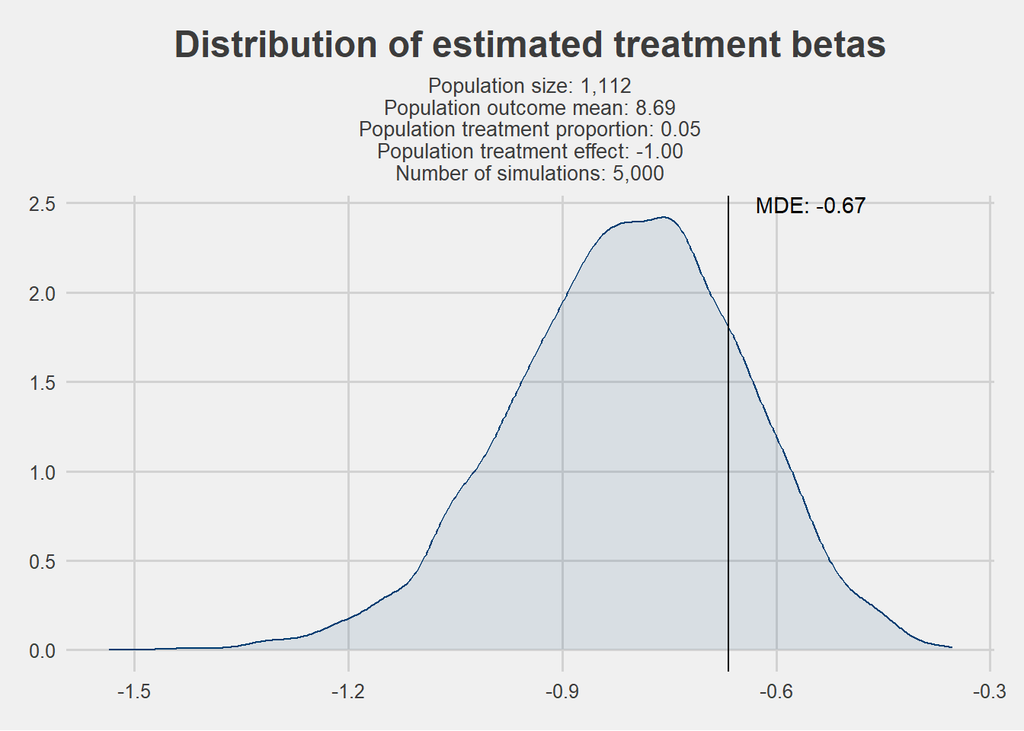

```r
ggplot() +
  geom_density(data = prep_02,
         aes(x = estimate, color = term, fill = term),
         alpha = .1) +
  geom_vline(data = prep_01, aes(xintercept = value)) +
  geom_text(data = prep_01, aes(x = value, label=label, y=Inf), hjust = -0.25,vjust = 1) +
  ggthemes::theme_fivethirtyeight() +
  scale_color_oes() +
  scale_fill_oes() +
  labs(
    title = "Distribution of estimated treatment betas",
    subtitle = glue::glue("Population size: {scales::comma(population_size_color_contrast_issues)}
                          Population outcome mean: {scales::comma(population_mean_color_contrast_issues, accuracy = .01)}
                          Population treatment proportion: {scales::comma(population_treatement_proportion, accuracy = .01)}
                          Population treatment effect: {scales::comma(params$ate, accuracy = .01)}
                          Number of simulations: {scales::comma(params$simulations)}
                          ")
  ) +
  theme(
    legend.position = "none",
    plot.title = element_text(hjust = 0.5),
    plot.subtitle = element_text(hjust = 0.5,
                                 size = 10)
  )
```